# Biometry

PCB 6455 / BSC 4933: Biometry | Lecture 1

Dr. Brian Maitner

## Today’s agenda

1. Introductions
2. Syllabus
3. Why we need stats
4. Reproducibility and Openness

## Introductions

**Please take a moment to tell us about yourself:**

01

Your Name

Introduce yourself to the class, including what you prefer to be called and your pronouns if you’d like to share.

02

Research

Describe your current research interests, what systems or questions you study, or what you hope to work on.

03

Fun Fact

Tell us something interesting or unique about yourself: hobbies, favorite travel spots, pets, or hidden talents!

## Syllabus: basic stuff

Class Meeting Days: T, Th  
Class Meeting Time: 2:00 to 3:50 pm  
Class Meeting Location: DAV 265  
Instructor: Dr. Brian Maitner  
Office Location: DAV 226 (but I’m usually in URL 106, because it’s warmer)  
Office Hours: TBD - ?  
Email: bmaitner@usf.edu

Up to date syllabus: https://github.com/bmaitner/biometry_course

## Course Github page

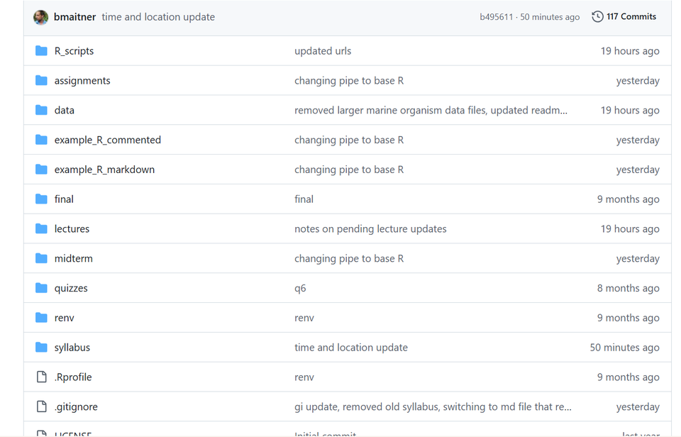

**Full of useful stuff:** the syllabus, the lectures, and previous quizzes.

## Syllabus: Course structure

Flipped course: read before class, work during class

Assignments will focus on data of your choosing

| **Graded Item** | **Percent of Final Grade** |
| --- | --- |
| In-class participation | 20% |
| In-class quizzes | 20% |
| Assignments (4x) | 20% |
| Midterm (take-home) | 20% |
| Final (presentation + take-home) | 20% |

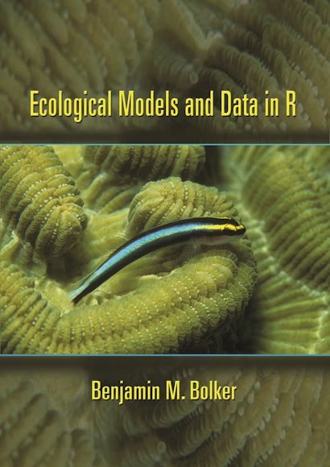

Digital copies available through the library for free

## Course Expectations

💬

Participate!

Ask questions. Share ideas, experiences, and knowledge!

🙂

Be Respectful.

Create a welcoming environment for everyone to learn, collaborate, and grow together.

## Recommendations

📋

Read the syllabus

📖

Read the book

✏️

Take notes on paper

📅

Plan ahead

💻

Bring a laptop

## Questions so far?

## What will you get out of this class?

In general:

📊

Practical Application

Ability to do common analyses and visualizations

📈

Future Growth

Ability to go further on your own

## What will you get out of this class?

More specifically:

Data & Visualization

Load data into R & perform common data-wrangling

Create plots using base R & ggplot2

Stats & Analysis

Understand key statistical distributions and applications

Select correct analyses for ecological datasets

Problem Solving

Troubleshoot & debug R code effectively

Approach novel coding challenges with confidence

Apply new programming skills directly to your own work

## Learning Stats

People learn differently and stats can be non-intuitive

The Book

Exposes you to verbal and mathematical descriptions of key statistical concepts.

In Class

Hands-on coding and interactive visualizations help build intuitive understanding.

The Goal

Providing multiple teaching methods ensures that at least one appeals to everyone.

## Learning Stats

What to Avoid

**Don’t focus on memorization**

What to Focus On

**DO focus on practice and understanding**

## A Note on AI

Establishing core fundamentals before leveraging artificial intelligence

Timing

We’ll cover AI later in the semester, once the foundations are established.

Approach

Strongly recommend that you start out without it to truly grasp the mechanics.

Requirement

You need reasonable fundamentals to be able to effectively and safely use AI.

## Questions so far?

# Why do we need statistics?

## Why do we need statistics?

01 . Cognitive Limits

Imperfect Minds

We must overcome human biases, logical fallacies, and cognitive limitations.

02 . Measurement

Effect Sizes

Accurately quantifying the strength and magnitude of different relationships.

03 . Validation

Hypothesis Testing

Systematically validating assumptions against empirical data.

04 . Forecasting

Making Predictions

Building robust models to anticipate future outcomes and trends.

05 . Clarity

Visualizations

Making complex numerical relationships instantly clear and intuitive.

06 . Etc

Lots of Other Stuff

From optimizing systems to driving data-informed strategic decisions.

## What is R and why is it useful?

The Core Idea

Scripted Language

**Type commands** instead of clicking buttons. This fundamental shift unlocks precision and power in data analysis.

Reproducibility

Easily Re-run & Revise Analyses

Modify your inputs or parameters and re-execute entire workflows instantly.

Efficiency

Re-use Code Across Projects

Build on top of previous work by recycling robust scripts for new datasets.

Documentation

Code as a Methods Section

Your codebase serves as a transparent, step-by-step record of your methodology.

## What is R and why is it useful?

01 . Cost-Effective

R is Free to Use

Anyone can download and use R without licensing costs, lowering the barrier to entry.

02 . Extensibility

User-Contributed Packages

A massive ecosystem of user-developed packages is contributed for free, extending its capabilities.

03 . Versatility

Incredible Flexibility

The vast range of libraries allows researchers to handle virtually any quantitative analysis task.

04 . Community

Popular & Supported

An active, global developer and user base provides vast documentation and peer-to-peer help.

## What is R and why is it useful?

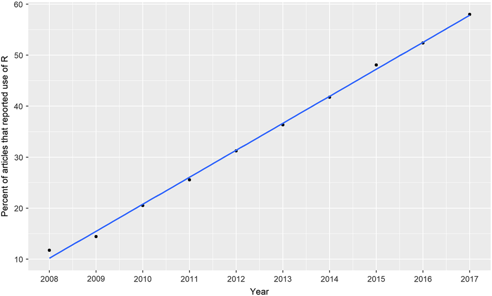

[figure not shown]

Lai et al. (2019), *Ecosphere* 10: e02567. CC BY 4.0

## What is R and why is it useful?

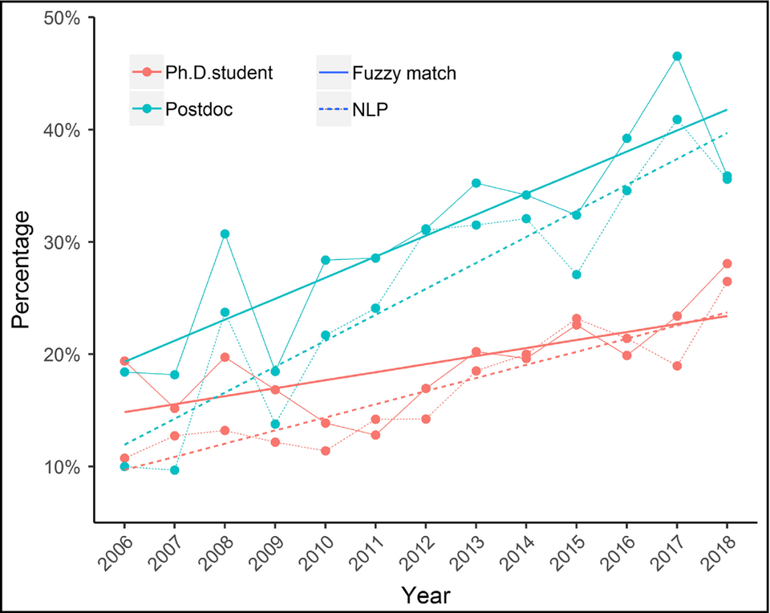

Front Ecol Environ 2020; 18(3): 123–124

## Transparency & Reproducibility

Science needs to be open, clear, and verifiable.

👁️

Transparency

What was done is clear

🔄

Reproducibility

Can be re-done with the same results

R helps with both of these!

## Transparency and Reproducibility

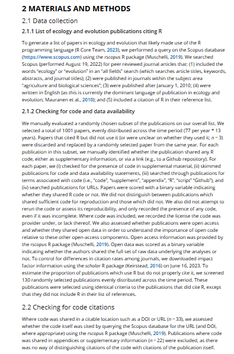

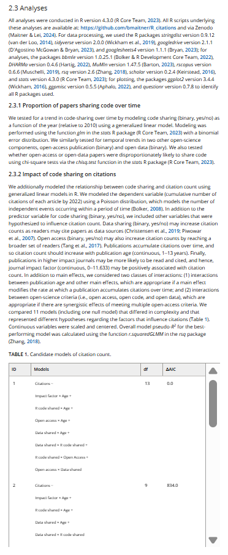

[figure not shown]

[figure not shown]

Maitner et al. (2024), *Ecology and Evolution* 14: e70030. CC BY 4.0

## Transparency and Reproducibility

Note: many journals and funders are now requiring code to be published

## Questions on any of this?

## Before next class

Read Bolker **1.1 to 1.3**

Next class: discuss 1.1 to 1.3, then install and set up R, RStudio and GitHub (if needed)